# 06: Linear models

```python
%matplotlib inline

import numpy as np
import pandas as pd
import matplotlib.pyplot as plt

import mylib as my
```

# Linear regression

Here we have $n$ examples each with $m$ features. For a single example $(\mathbf{x}, y)$ The linear regression model is written as: $$h(\mathbf{x}) = w_0 + w_1 x_1 + w_2 x_2 + \cdots + w_m x_m$$ where $w_0, w_1, \cdots, w_m$ are the weight parameters we are trying to learn.

NOTE: In the multidimensional case, we have a regression hyperplane instead of a regression line.

We can express this model for a single example using the matrix notation like this:

$$h(\mathbf{x}) = \mathbf{w}^T \mathbf{x}$$

For the entire training dataset, we have: $$h(\mathbf{X}) = \mathbf{X} \mathbf{w}$$

### Using the normal equation

Using the $L_2$ loss function which is defined as:

$$L_2 = \frac{1}{2} \sum_{i=1}^n (y^{(i)} - h(\mathbf{x}^{(i)}))^2 = \frac{1}{2} \sum_{i=1}^n (y^{(i)} - \mathbf{w}^T \mathbf{x}^{(i)})^2$$

or in matrix notation as: $$L_2 = \frac{1}{2} (\mathbf{y} - h(\mathbf{X}))^T(\mathbf{y} - h(\mathbf{X})) = \frac{1}{2} (\mathbf{y} - \mathbf{X} \mathbf{w})^T(\mathbf{y} - \mathbf{X} \mathbf{w})$$

We can use the following equation to find the weight parameters $\mathbf{w}$ that minimize the loss equation $L_2$:

$$ \mathbf{w} = (\mathbf{X}^T \mathbf{X} )^{-1} \mathbf{X}^T \mathbf{y}$$

```python
class LinearRegressor:
    def __init__(self, dataset):
        self.ds = dataset

    def fit(self):
        X = np.concatenate((np.ones((self.ds.N, 1)), self.ds.inputs), axis=1)
        y = self.ds.target.ravel()
        self.w = np.dot(np.linalg.pinv(X), y)

    def predict(self, unseen):
        if unseen.ndim == 1:
            x = np.insert(unseen, 0, 1) # adding the bias weight
            return np.dot(x, self.w)
        else:
            return np.array([self.predict(ex) for ex in unseen])
```

Let's test it. First we create a sample dataset:

```python
x = np.arange(0, 15, .1)
y = 2 * x + 2 + np.random.normal(loc=2, scale=5, size=len(x))

df = pd.DataFrame({'x': x, 'y': y})
data = my.DataSet(df, y=True)

x,y
```

```
(array([ 0. ,  0.1,  0.2,  0.3,  0.4,  0.5,  0.6,  0.7,  0.8,  0.9,  1. ,
         1.1,  1.2,  1.3,  1.4,  1.5,  1.6,  1.7,  1.8,  1.9,  2. ,  2.1,
         2.2,  2.3,  2.4,  2.5,  2.6,  2.7,  2.8,  2.9,  3. ,  3.1,  3.2,
         3.3,  3.4,  3.5,  3.6,  3.7,  3.8,  3.9,  4. ,  4.1,  4.2,  4.3,
         4.4,  4.5,  4.6,  4.7,  4.8,  4.9,  5. ,  5.1,  5.2,  5.3,  5.4,
         5.5,  5.6,  5.7,  5.8,  5.9,  6. ,  6.1,  6.2,  6.3,  6.4,  6.5,
         6.6,  6.7,  6.8,  6.9,  7. ,  7.1,  7.2,  7.3,  7.4,  7.5,  7.6,
         7.7,  7.8,  7.9,  8. ,  8.1,  8.2,  8.3,  8.4,  8.5,  8.6,  8.7,
         8.8,  8.9,  9. ,  9.1,  9.2,  9.3,  9.4,  9.5,  9.6,  9.7,  9.8,
         9.9, 10. , 10.1, 10.2, 10.3, 10.4, 10.5, 10.6, 10.7, 10.8, 10.9,
        11. , 11.1, 11.2, 11.3, 11.4, 11.5, 11.6, 11.7, 11.8, 11.9, 12. ,
        12.1, 12.2, 12.3, 12.4, 12.5, 12.6, 12.7, 12.8, 12.9, 13. , 13.1,
        13.2, 13.3, 13.4, 13.5, 13.6, 13.7, 13.8, 13.9, 14. , 14.1, 14.2,
        14.3, 14.4, 14.5, 14.6, 14.7, 14.8, 14.9]),
 array([12.43794006,  5.81088706, -2.09340336,  6.32351384, -4.08983818,
        12.55773994,  6.4863457 ,  6.88205874,  0.99692261,  7.51341318,
        12.52876575,  4.21461207, -2.46884715, 13.62522661, 11.12116312,
         9.49094792, 14.17189928,  8.24243553,  8.67020581,  2.0830516 ,
        12.43077049, 10.27732727, 13.83898844,  8.85598311, 13.48052473,
        13.26832294, 10.58655759,  9.15391285, 12.08086799, 11.27338592,
        10.78377523,  6.80982231, 12.15902807, 16.81585275, 18.62444217,
         7.72553575, 12.80216194, 12.76774992,  4.80439509, 10.58845944,
        15.19541614, 12.91906248, 13.43584798, 11.0849438 , 23.59354382,
        10.7538626 , 16.97278152, 12.67963751, 17.32859079,  6.41798023,
        18.37695818, 12.28545657, 20.70240898, 20.19823308, 14.72512094,
        15.72099724, 17.39713292, 20.97052509, 16.29542887, 21.61529606,
        14.28171549, 27.04219723, 14.80854135, 15.56152157,  8.49593703,
        16.82588503, 14.22616371, 17.53301014,  6.44950658, 13.21322474,
        20.06993717, 13.53692925, 28.05760935, 17.97059122, 16.71555269,
        15.61431445, 18.04473316, 24.65328481, 15.40244191, 17.50782622,
        17.24149421, 28.79272845, 17.1966166 , 13.67227978, 18.8734215 ,
        24.57831224, 17.22148455, 18.63869491, 30.03545373, 20.65046917,
        21.90104241, 26.81004166, 14.07435862, 20.36920793, 24.07003966,
        22.66985827, 24.3456301 , 24.78756016, 24.75253201, 24.07635534,
        17.58283551, 22.85929348, 24.26692763, 17.19590388, 24.58811391,
        19.50745099, 24.61097067, 29.13371256, 15.39748437, 17.20602122,
        22.62746028, 16.79372407, 24.04056859, 26.22864672, 26.30341641,
        24.23206021, 32.67516336, 30.17362158, 32.42923746, 18.62306868,
        26.24557061, 26.20562285, 25.17606918, 28.14786505, 35.35285301,
        33.71530546, 27.49811308, 25.30226898, 24.38182183, 29.61756233,
        24.80174683, 33.76164688, 29.50456101, 30.38308475, 25.99312728,
        34.91839914, 25.13131819, 40.69634887, 33.37693254, 27.59653683,
        25.41674278, 22.51273342, 34.62284742, 38.36340879, 34.36664193,
        33.18855725, 39.25935852, 40.07510554, 41.53148466, 36.22277672]))
```

Let's plot this data:

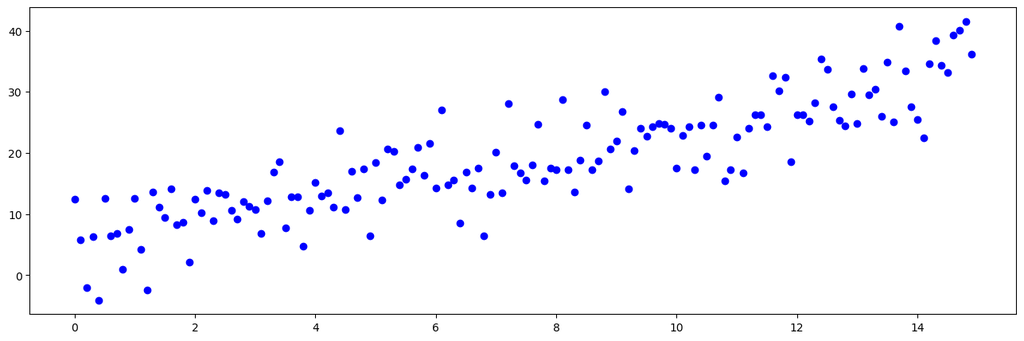

```python
# plottong
fig = plt.figure(figsize=(16,5))
plt.scatter(x, y, color='b', marker='o')
```

Let's fit this data using the above linear regression:

```python
lg = LinearRegressor(data)
lg.fit()

print (lg.w)
```

```
[5.29780465 1.84182732]
```

And here is the regression line:

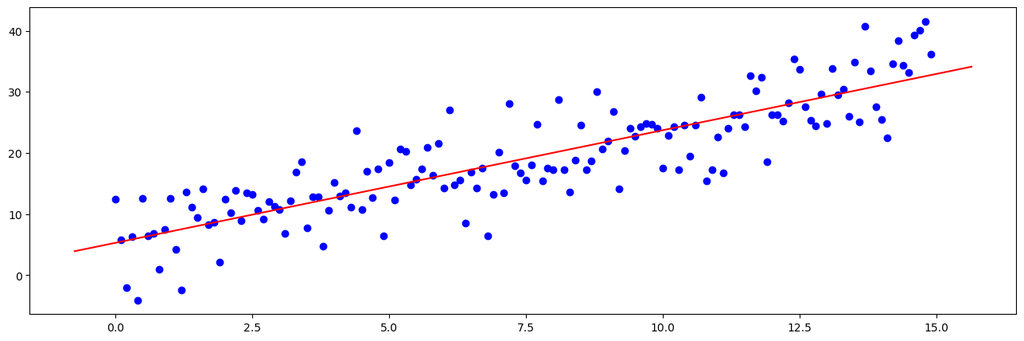

```python
fig = plt.figure(figsize=(16,5))
ax = fig.add_subplot(1, 1, 1)
ax.scatter(x, y, color='b', marker='o')

x1, x2 = ax.get_xlim()

input = np.array([[x1], [x2]])
output = lg.predict(input)

ax.plot((x1, x2), output.ravel(), 'r-')
```

### Using gradient descent

Given a loss function $L(\mathbf{w})$, we can try to find $\mathbf{w}$ that minimizes the loss function using gradient descent:

$$\mathbf{w} = \mathbf{w} - \eta \nabla L(\mathbf{w})$$

where $\eta$ is the learning rate and $\nabla L(\mathbf{w})$ is the gradient (a vector of partial derivatives one for each $w_i$).

For a single weight $w_i$ given a single example $(\mathbf{x}, y)$.

$$w_i = w_i - \eta \frac{\delta L(\mathbf{w})}{\delta w_i}$$

If $L$ is $L_2$ then: $$w_i = w_i - \eta \frac{\delta\ \ \frac{1}{2}(y - \mathbf{w}^T \mathbf{x})^2}{\delta w_i}$$

which gives us the update rule: $$w_i = w_i + \eta (y - \mathbf{w}^T \mathbf{x}) x_i$$

```python
class GDLinearRegressor:
    def __init__(self, dataset, eta=.0001, epochs=10, random_state=17):
        self.ds = dataset
        self.eta = eta
        self.epochs = epochs
        self.random_state = random_state

    def fit(self):
        X = np.concatenate([np.ones(self.ds.N).reshape(self.ds.N, 1), self.ds.inputs], axis=1)
        n = X.shape[0]
        m = X.shape[1]
        rgen = np.random.RandomState(self.random_state)
        self.w = rgen.normal(loc=0.0, scale=0.01, size=m).reshape(m, 1)

        self.loss_hist = []
        for e in range(self.epochs):
            predicted = np.dot(X, self.w)
            error = self.ds.target - predicted
            loss = (1/n) * np.dot(error.T, error) # dividing by n to scale the cost down
            self.loss_hist.append(loss[0,0] / n)
            self.w = self.w + (self.eta) * np.dot(X.T, error)

    def predict(self, unseen):
        if unseen.ndim == 1:
            x = np.insert(unseen, 0, 1) # adding the bias weight
            return np.dot(x, self.w)
        else:
            return np.array([self.predict(ex) for ex in unseen])
```

Let's test it using the same dataset as above:

```python
gd = GDLinearRegressor(data)
gd.fit()

print(gd.w)
```

```
[[0.42773968]
 [2.33211324]]
```

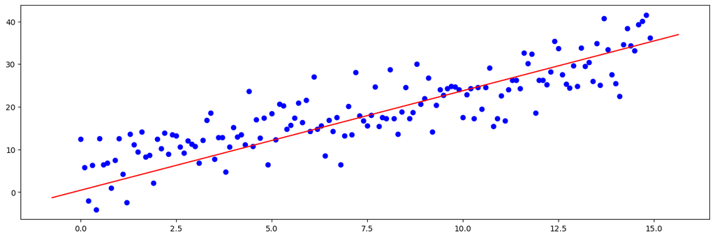

```python
fig = plt.figure(figsize=(16,5))
ax = fig.add_subplot(1, 1, 1)

ax.scatter(x, y, color='b', marker='o')

x1, x2 = ax.get_xlim()

input = np.array([[x1], [x2]])
output = gd.predict(input)

ax.plot((x1, x2), output.ravel(), 'r-')
```

### The learning curve

Here a plot showing how our gradient descent implementation behave as number of epochs grows (an epoch is a one pass over the entire training dataset).

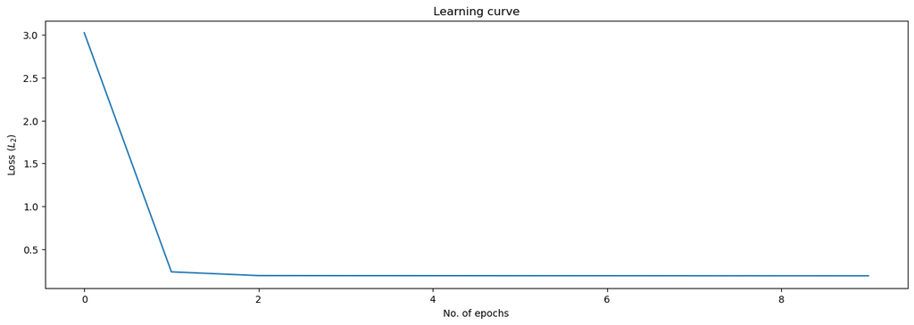

```python
gd = GDLinearRegressor(data)
gd.fit()

fig = plt.figure(figsize=(16, 5))

plt.title('Learning curve')
plt.xlabel('No. of epochs')
plt.ylabel('Loss ($L_2$)')
plt.plot(gd.loss_hist)
```

### Changing epochs and $\eta$

And we can even plot the regression lines after various numbers of epochs (an epoch is a one pass over the entire training dataset).

When the learning rate $\eta$ is just about right, the convergence happens quickly.

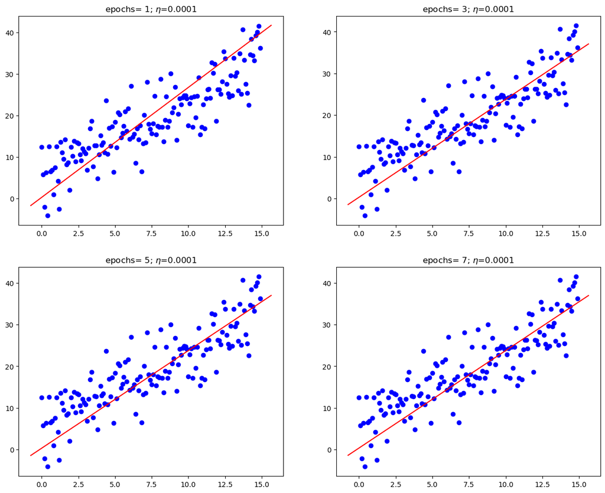

```python
fig = plt.figure(figsize=(15,25))
n = 4
eta = 0.0001
for i in range(n):
    gd = GDLinearRegressor(data, eta=eta, epochs=2 * i + 1)
    gd.fit()
    ax = fig.add_subplot(n, 2, i + 1)
    ax.scatter(x, y, color='b', marker='o')

    x1, x2 = ax.get_xlim()

    input = np.array([[x1], [x2]])

    output = gd.predict(input)

    ax.plot((x1, x2), output.ravel(), 'r-')
    plt.title(f'epochs= {2 * i + 1}; $\eta$=0.0001')
```

When the learning rate $\eta$ is small, the convergence takes more epochs.

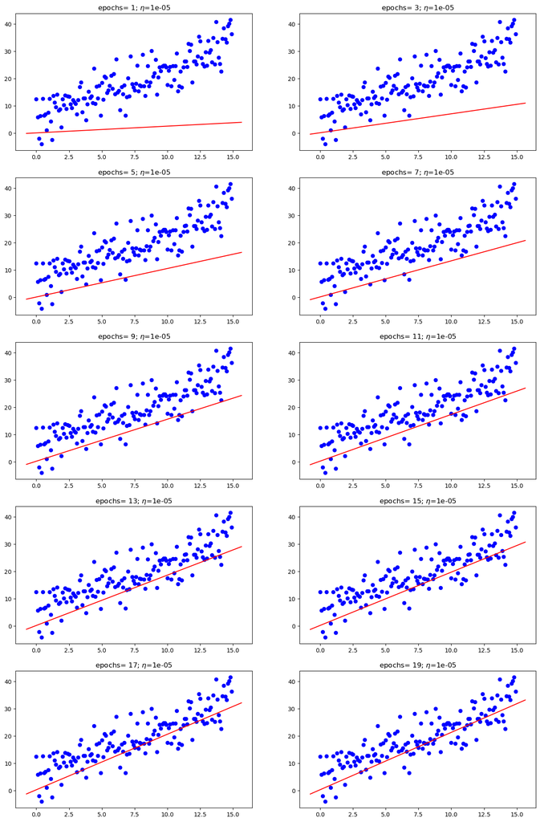

```python
fig = plt.figure(figsize=(16,50))
n = 10
eta = 0.00001
for i in range(n):
    gd = GDLinearRegressor(data, eta=eta, epochs=2 * i + 1)
    gd.fit()
    ax = fig.add_subplot(n, 2, i + 1)
    ax.scatter(x, y, color='b', marker='o')

    x1, x2 = ax.get_xlim()

    input = np.array([[x1], [x2]])

    output = gd.predict(input)

    ax.plot((x1, x2), output.ravel(), 'r-')
    plt.title(f'epochs= {2 * i + 1}; $\eta$={eta}')
```

And here is it when the learning rate $\eta$ is too large.

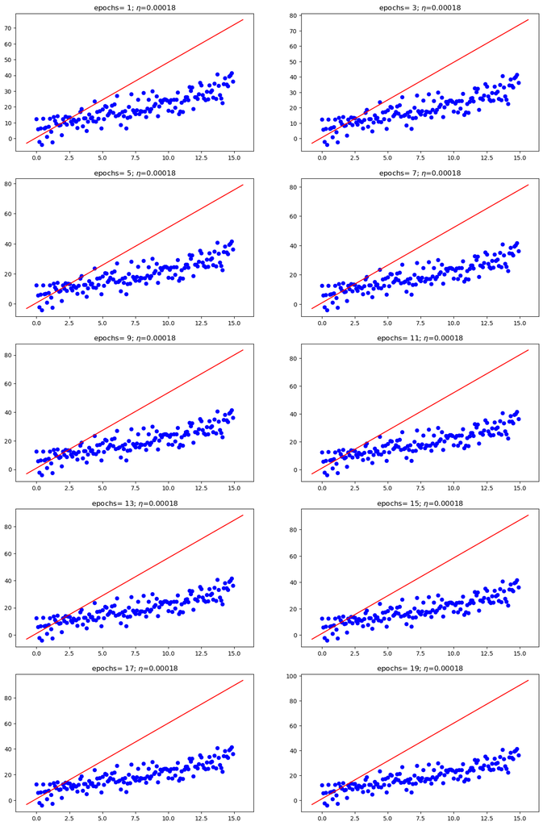

```python
fig = plt.figure(figsize=(16,50))
n = 10
eta = 0.00018
for i in range(n):
    gd = GDLinearRegressor(data, eta=eta, epochs=2 * i + 1)
    gd.fit()
    # make it just i so that i +1 is the learning curve
    ax = fig.add_subplot(n, 2, i+1)
    ax.scatter(x, y, color='b', marker='o')

    x1, x2 = ax.get_xlim()

    input = np.array([[x1], [x2]])

    output = gd.predict(input)

    ax.plot((x1, x2), output.ravel(), 'r-')
    plt.title(f'epochs= {2 * i + 1}; $\eta$={eta}')
```

## CHALLENGE A

Take the above plots where $\eta$ is too big and draw next to each plot its corresponding learning curve.

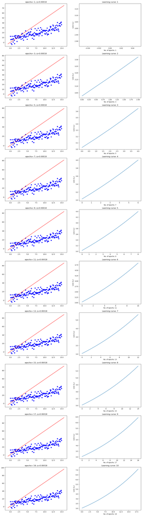

```python
# TODO combine these two ideas into neighbors

# example where eta is too big
n = 10
eta = 0.00018

fig,axes = plt.subplots(n, 2)
fig.set_size_inches(16,60)

# amount of epochs tried
for i in range(0,n):
    j = 0

    # Plot of different sized epochs with large eta
    gd = GDLinearRegressor(data, eta=eta, epochs=2 * i + 1)
    gd.fit()

    axes[i,j].scatter(x, y, color='b', marker='o')

    x1, x2 = axes[i,j].get_xlim()

    input = np.array([[x1], [x2]])

    output = gd.predict(input)

    axes[i,j].plot((x1, x2), output.ravel(), 'r-')
    axes[i,j].set_title(f'epochs= {2 * i + 1}; $\eta$={eta}')

    # Plot of Learning curve for each
    j += 1
    axes[i,j].plot(gd.loss_hist)
    axes[i,j].set_title(f'Learning curve: {i+1}')
    axes[i,j].set_xlabel(f'No. of epochs: {2*i+1}')
    axes[i,j].set_ylabel('Loss ($L_2$)')
```

## Logistic regression

We can write $h(\mathbf{X})$ as:

$$ h(\mathbf{X}) = g(\mathbf{X} \mathbf{w}) = g(z)$$

For linear regression: $$ g(z) = z $$

and for logistic regression: $$ g(z) = \frac{1}{1 + e^{-z}} $$

where $g$ is the **logistic** or **sigmoid** function, which is defined as:

$$ h(\mathbf{X}) = \frac{1}{1 + e^{- \mathbf{X} \mathbf{w}}} $$

This means that $h(\mathbf{X}) \in [0, 1]$, which means that it can be interpreted as a probability:

$$ p(y | \mathbf{x}; \mathbf{w}) = {\begin{cases}h(\mathbf{x})& {\text{ if }}y = 1\\1 - h(\mathbf{x})&{\text{ if }} y = 0\end{cases}} $$

which can be written as: $$ p(y | \mathbf{x}; \mathbf{w}) = h(\mathbf{x})^y (1 - h(\mathbf{x}))^{1 - y} $$

In addition, given the sigmoid function $$ g(z) = \frac{1}{1 + e^{-z}}$$

it can be shown that:

$$g'(z) = \frac{d}{dz} \frac{1}{1 + e^{-z}} = g(z) (1 - g(z))$$

```python
class LogisticRegression:
    def __init__(self, dataset, eta=.0001, epochs=100, random_state=17):
        self.ds = dataset
        self.eta = eta
        self.epochs = epochs
        self.random_state = random_state

    def sigmoid(self, z):
        return 1 / (1 + np.exp(-z))

    def fit(self):
        X = np.concatenate([np.ones(self.ds.N).reshape(self.ds.N, 1), self.ds.inputs], axis=1)
        n = X.shape[0]
        m = X.shape[1]
        rgen = np.random.RandomState(self.random_state)
        self.w = rgen.normal(loc=0.0, scale=0.01, size=m).reshape(m, 1)
        for i in range(self.epochs):
            z = np.dot(X, self.w)
            h = self.sigmoid(z)
            self.w = self.w + self.eta * np.dot(X.T, (self.ds.target - h))

    def predict(self, unseen, threshold=.5):
        """ Returns probabilites unless a valid threshold is given"""
        if unseen.ndim == 1:
            x = np.insert(unseen, 0, 1) # adding the bias weight

            if threshold != None and 0.0 < threshold < 1.0:
                return 1 if self.sigmoid(np.dot(x, self.w)) >= threshold else 0
            else:
                return self.sigmoid(np.dot(x, self.w))
        else:
            return np.array([self.predict(ex, threshold) for ex in unseen])
```

To see how this logistic classifier works, let's generate some data.

### Example 1: one-dimensional data

We start by generating one-dimensional data with two classes (0 and 1).

```python
n = 300
data = np.array([[3, 14],[10, 9]])

# Group A: data with class 0
d0 = np.concatenate((data[0, 1] + np.random.normal(loc=1, scale=1.3, size=(n, 1)),
                     np.zeros(n).reshape(n, 1)), axis= 1)
# Group B: data with class 1
d1 = np.concatenate((data[1, 1] + np.random.normal(loc=.5, scale=1.3, size=(n, 1)),
                     np.ones(n).reshape(n, 1)), axis= 1)

# Combining both sets into one dataset
d = np.concatenate((d0, d1), axis=0)
data = my.DataSet(pd.DataFrame(d, columns=['x', 'y']), y=True)
```

Let's plot this data:

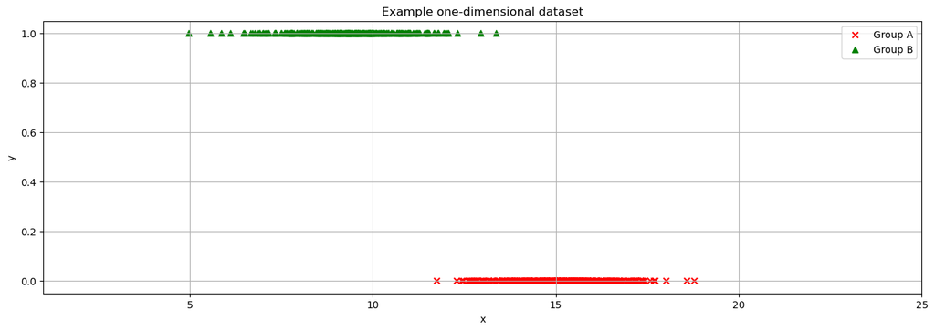

```python
def color_by_label(ds):
    return list(map(lambda y: 'r' if y == 0 else 'g', ds))

fig = plt.figure(figsize=(16,5))
ax = fig.add_subplot(1, 1, 1)

a_ = data.examples[data.examples['y'] == 0]
ax.scatter(a_.iloc[:, 0], a_.iloc[:, 1], c=color_by_label(a_['y'].to_list()), marker='x', label='Group A')

b_ = data.examples[data.examples['y'] == 1]
ax.scatter(b_.iloc[:, 0], b_.iloc[:, 1], c=color_by_label(b_['y'].to_list()), marker='^', label='Group B')

ax.set_xlim(1,25)
ax.set_xlabel('x')
ax.set_ylabel('y')
ax.set_title('Example one-dimensional dataset')
ax.legend(loc='best')
ax.grid()
```

We have a few hyper parameters to consider. So let's spit this dataset into test, validation, and training.

```python
rest, test = data.train_test_split(test_portion=0.20, shuffle=True)
train, valid = data.train_test_split(test_portion=0.20)
```

We now train a logistic regression classifier:

```python
logr = LogisticRegression(train)
logr.fit()
print(logr.w)
```

```
[[ 0.42723651]
 [-0.10434148]]
```

Let's test it:

```python
cm = my.confusion_matrix(train.target, logr.predict(train.inputs))
accuracy = np.trace(cm) / np.sum(cm)

print(cm)
print('Training accuracy: ', accuracy)

cm = my.confusion_matrix(test.target, logr.predict(test.inputs))
accuracy = np.trace(cm) / np.sum(cm)

print(cm)
print('Test accuracy: ', accuracy)
```

```
[[300   0]
 [180   0]]
Training accuracy:  0.625
[[63  0]
 [57  0]]
Test accuracy:  0.525
```

which is not good. Can we improve it? Let's see if increasing the number of epochs helps. We'll use the validation dataset here to determine a good value for `epochs`.

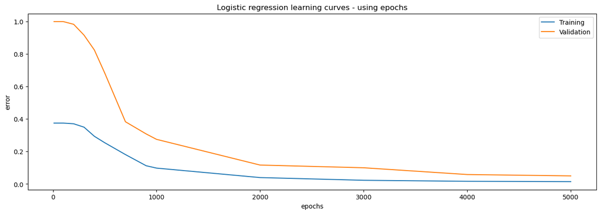

```python
epochs = [10, 100, 200, 300, 400, 500, 700, 900, 1000, 2000, 3000, 4000, 5000]
train_err = []
valid_err = []
for n in epochs:
    logr = LogisticRegression(train, epochs=n)
    logr.fit()

    cm = my.confusion_matrix(train.target, logr.predict(train.inputs))
    train_err.append(1 - np.trace(cm) / np.sum(cm))

    cm = my.confusion_matrix(valid.target, logr.predict(valid.inputs))
    valid_err.append(1 - np.trace(cm) / np.sum(cm))

fig = plt.figure(figsize=(16,5))
ax = fig.add_subplot(1, 1, 1)
ax.plot(epochs, train_err, label="Training")
ax.plot(epochs, valid_err, label="Validation")
ax.set_xlabel("epochs")
ax.set_ylabel("error")
ax.legend()
ax.set_title("Logistic regression learning curves - using epochs")
```

From the plot above, an `epochs` value around `3000` (which can change from one run to another) seems reasonable. Let's test with it:

```python
logr = LogisticRegression(train, epochs=3000)
logr.fit()

cm = my.confusion_matrix(test.target, logr.predict(test.inputs))
accuracy = np.trace(cm) / np.sum(cm)

print(cm)
print('Test accuracy: ', accuracy)
```

```
[[63  0]
 [ 2 55]]
Test accuracy:  0.9833333333333333
```

which is much much better.

Here is a plot of the above data with the logistic (sigmoid) function imposed on it to show you how logistic regression works. Can you spot the misclassified examples?

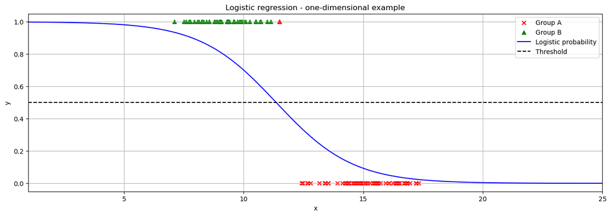

```python
fig = plt.figure(figsize=(16,5))
ax = fig.add_subplot(1, 1, 1)

a_ = test.examples[test.examples['y'] == 0]
# print(a_.iloc[:,:-1].to_numpy())
predicted = logr.predict(a_.iloc[:,:-1].to_numpy())
ax.scatter(a_.iloc[:, 0], a_.iloc[:, 1], c=color_by_label(predicted), marker='x', label='Group A')

b_ = test.examples[test.examples['y'] == 1]
predicted = logr.predict(b_.iloc[:,:-1].to_numpy())
ax.scatter(b_.iloc[:, 0], b_.iloc[:, 1], c=color_by_label(predicted), marker='^', label='Group B')

# plotting the logistic (sigmoid) function
x = np.linspace(1, 25, 200).reshape(200, 1)
p = logr.predict(x, threshold=None)
ax.plot(x, p, color='blue', label='Logistic probability')

ax.plot([1, 25], [.5, .5], linestyle='dashed', color='k', label='Threshold')

ax.set_xlim(1,25)
ax.set_xlabel('x')
ax.set_ylabel('y')
ax.set_title('Logistic regression - one-dimensional example')
ax.legend(loc='best')
ax.grid()
```

### Example 2: two-dimensional data

We now generate two-dimensional data with two features ($x_1$, $x_2$) and an output column with two classes (0, 1):

```python
n = 150
data = np.array([[3, 14],[10, 9]])
d0 = np.concatenate((data[0,0] + np.random.normal(loc=1, scale=2.8, size=(n, 1)),
                data[0, 1] + np.random.normal(loc=1, scale=1.2, size=(n, 1)), np.zeros(n).reshape(n, 1)), axis= 1)

d1 = np.concatenate((data[1,0] + np.random.normal(loc=.5, scale=2.5, size=(n, 1)),
                data[1, 1] + np.random.normal(loc=.5, scale=1, size=(n, 1)), np.ones(n).reshape(n, 1)), axis= 1)


d = np.concatenate((d0, d1), axis=0)
data = my.DataSet(pd.DataFrame(d, columns=['x1', 'x2', 'y']), y=True)
```

Here is how the generated data looks like:

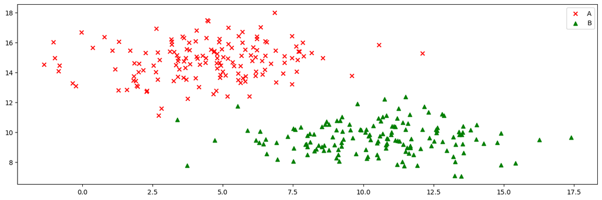

```python
fig = plt.figure(figsize=(16,5))
ax = fig.add_subplot(1, 1, 1)
a_ = data.examples[data.examples['y'] == 0].iloc[:, :-1].values
ax.scatter(a_[:, 0], a_[:, 1], color='red', marker='x', label='A')

b_ = data.examples[data.examples['y'] == 1].iloc[:, :-1].values
ax.scatter(b_[:, 0], b_[:, 1], color='green', marker='^', label='B')

ax.legend(loc='best')
```

We now split this data into training and test sets.

```python
train, test = data.train_test_split(test_portion=0.33, shuffle=True)
```

We train our logistic regression classifier and display the learned weights.

```python
logr = LogisticRegression(train)
logr.fit()
print(logr.w)
```

```
[[ 0.03186971]
 [ 0.69011358]
 [-0.43836601]]
```

which gives us the following confusion matrix and accuracy:

```python
cm = my.confusion_matrix(train.target, logr.predict(train.inputs))
accuracy = np.trace(cm) / np.sum(cm)

print(cm)
print('Training accuracy: ', accuracy)
```

```
[[103   2]
 [  3  93]]
Training accuracy:  0.9751243781094527
```

Here is the corresponding decision regions plot:

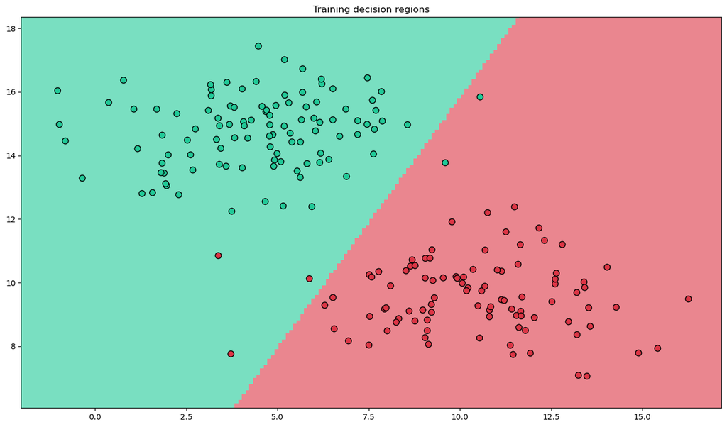

```python
my.plot_decision_regions(train.inputs, train.target, logr, resolution=0.1, title="Training decision regions")
```

Let's now test our trained logistic model:

```
[[44  1]
 [ 3 51]]
Test accuracy:  0.9595959595959596
```

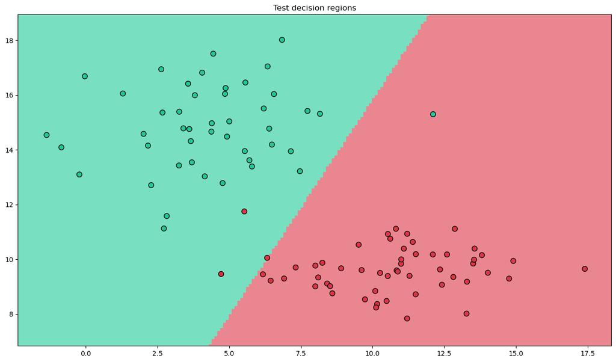

```python
cm = my.confusion_matrix(test.target, logr.predict(test.inputs, threshold=.5))
accuracy = np.trace(cm) / np.sum(cm)

print(cm)
print('Test accuracy: ', accuracy)

my.plot_decision_regions(test.inputs, test.target, logr, resolution=0.1, title="Test decision regions")
```

## CHALLENGE B

Using the method of the one-dimensional binary classification data example above, plot the learning curves you obtain by having a fixed `epochs=1000` and varying the learning rate $\eta$. You need to create your own data.

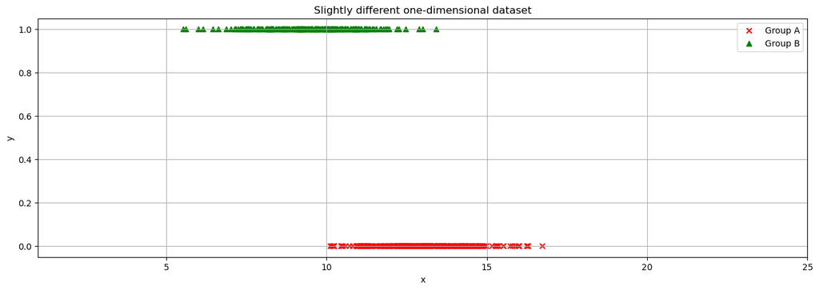

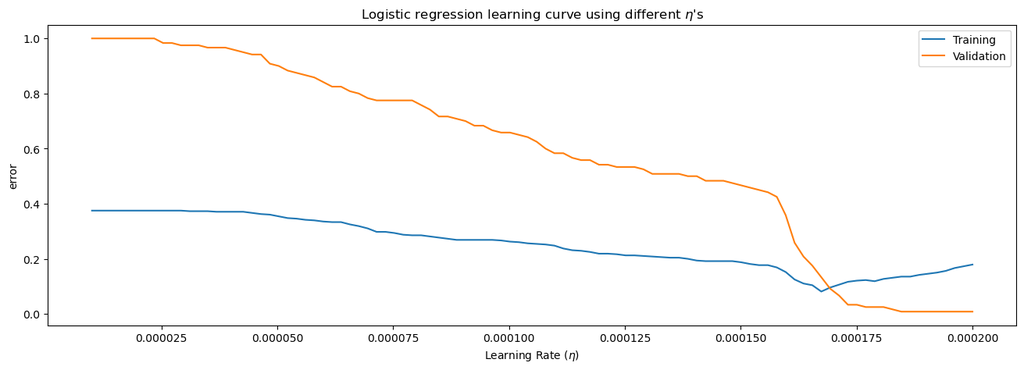

```python
# Making new data

n = 300
# make classes that have a good amount of separation but has more overlap than the example
new_data = np.array([[6, 12],[10, 9]])

# Group A: data with class 0
d0 = np.concatenate((new_data[0, 1] + np.random.normal(loc=1, scale=1.3, size=(n, 1)),
                     np.zeros(n).reshape(n, 1)), axis= 1)
# Group B: data with class 1
d1 = np.concatenate((new_data[1, 1] + np.random.normal(loc=.5, scale=1.3, size=(n, 1)),
                     np.ones(n).reshape(n, 1)), axis= 1)

# Combining both sets into one dataset
d = np.concatenate((d0, d1), axis=0)
data_ds = my.DataSet(pd.DataFrame(d, columns=['x', 'y']), y=True)


fig = plt.figure(figsize=(16,5))
ax = fig.add_subplot(1, 1, 1)

a_ = data_ds.examples[data_ds.examples['y'] == 0]
ax.scatter(a_.iloc[:, 0], a_.iloc[:, 1], c=color_by_label(a_['y'].to_list()), marker='x', label='Group A')

b_ = data_ds.examples[data_ds.examples['y'] == 1]
ax.scatter(b_.iloc[:, 0], b_.iloc[:, 1], c=color_by_label(b_['y'].to_list()), marker='^', label='Group B')

ax.set_xlim(1,25)
ax.set_xlabel('x')
ax.set_ylabel('y')
ax.set_title('Slightly different one-dimensional dataset')
ax.legend(loc='best')
ax.grid()

# make test, training, and validation sets
new_rest, new_test = data_ds.train_test_split(test_portion=0.20, shuffle=True)
new_train, new_valid = data_ds.train_test_split(test_portion=0.20)

etas = list(np.linspace(.00001, .0002, 100))
new_train_err = []
new_valid_err = []
# print(etas)

for ex in etas:
    # print(ex)
    logr = LogisticRegression(new_train, epochs=1000,eta=ex)
    logr.fit()

    cm = my.confusion_matrix(new_train.target, logr.predict(new_train.inputs))
    new_train_err.append(1 - np.trace(cm) / np.sum(cm))

    cm = my.confusion_matrix(new_valid.target, logr.predict(new_valid.inputs))
    new_valid_err.append(1 - np.trace(cm) / np.sum(cm))

fig = plt.figure(figsize=(16,5))
ax = fig.add_subplot(1, 1, 1)
ax.plot(etas, new_train_err, label="Training")
ax.plot(etas, new_valid_err, label="Validation")
ax.set_xlabel("Learning Rate $(\eta$)")
ax.set_ylabel("error")
ax.legend()
ax.set_title("Logistic regression learning curve using different $\eta$'s")
```